# How to {ggplot2}

Carlina Feldmann  
Lennart Oelschläger

Last rendered on 13.09.2022

# Why and what

Welcome to this tiny course on data visualization in R with [{ggplot2}](https://ggplot2.tidyverse.org/)! 👋

### Why do we care?

Potentially, plots can [beautifully inform](https://en.wikipedia.org/wiki/Charles_Joseph_Minard#The_map_of_Napoleon's_Russian_campaign) or [horribly mislead](https://en.wikipedia.org/wiki/Misleading_graph#Truncated_graph). [Colors](https://michaelbach.de/ot) and [shape](http://vis.stanford.edu/files/2010-MTurk-CHI.pdf) matter! ⚖️

### Why {ggplot2}?

The {ggplot2} package implements a *grammar of graphics*, a series of distinct tasks to make a graphic.

### What is this course about?

Being in decent control of {ggplot2} to produce meaningful plots.

### What do you need?

Basic R skills + a not-too-old version of R (>= 4.0.0) + RStudio

### At the end of the day…

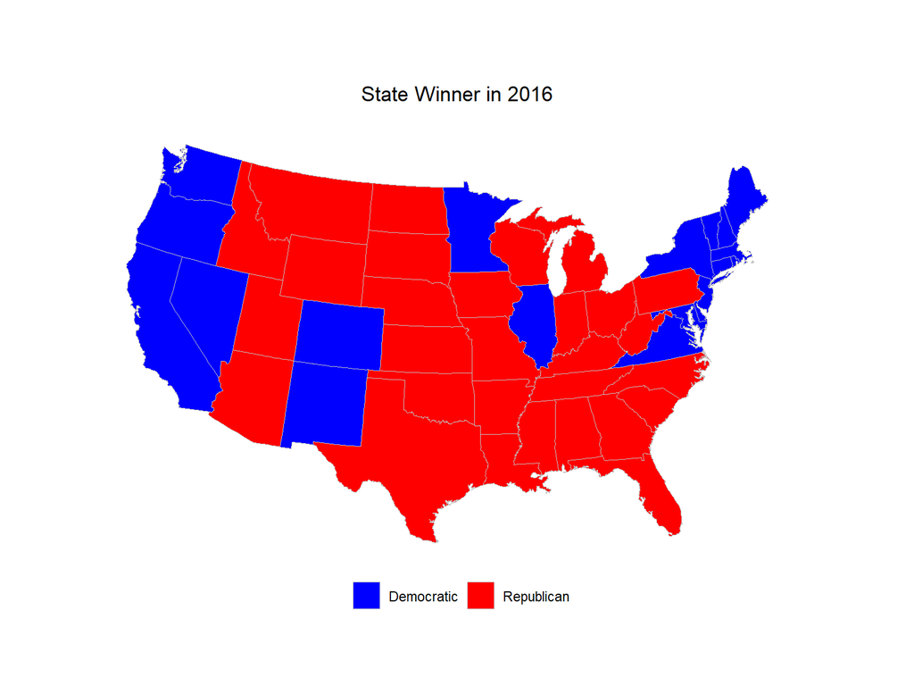

### Sources

- Healy (2019): [Data Visualization: A practical introduction](https://socviz.co/)
- Wickham (2016): [ggplot2: elegant graphics for data analysis](https://ggplot2-book.org/)
- Wilkinson (2005): The Grammar of Graphics
- Tufte (1983): The Visual Display of Quantitative Information

### Found mistakes? Have suggestions?

I’m sure you have! Please leave a note [here](https://github.com/loelschlaeger/howtoggplot2/issues/new/choose). 🙏

# Our first plot

Load {ggplot2}.

```r
# install.packages(ggplot2)
library(ggplot2)
```

We need data, let’s go with an excerpt from the famous [Gapminder dataset](https://www.gapminder.org/tools):

```r
# install.packages(gapminder)
library(gapminder)
head(gapminder)
```

```
## # A tibble: 6 × 6
##   country     continent  year lifeExp      pop gdpPercap
##   <fct>       <fct>     <int>   <dbl>    <int>     <dbl>
## 1 Afghanistan Asia       1952    28.8  8425333      779.
## 2 Afghanistan Asia       1957    30.3  9240934      821.
## 3 Afghanistan Asia       1962    32.0 10267083      853.
## 4 Afghanistan Asia       1967    34.0 11537966      836.
## 5 Afghanistan Asia       1972    36.1 13079460      740.
## 6 Afghanistan Asia       1977    38.4 14880372      786.
```

```r
str(gapminder)
```

```
## tibble [1,704 × 6] (S3: tbl_df/tbl/data.frame)
##  $ country  : Factor w/ 142 levels "Afghanistan",..: 1 1 1 1 1 1 1 1 1 1 ...
##  $ continent: Factor w/ 5 levels "Africa","Americas",..: 3 3 3 3 3 3 3 3 3 3 ...
##  $ year     : int [1:1704] 1952 1957 1962 1967 1972 1977 1982 1987 1992 1997 ...
##  $ lifeExp  : num [1:1704] 28.8 30.3 32 34 36.1 ...
##  $ pop      : int [1:1704] 8425333 9240934 10267083 11537966 13079460 14880372 12881816 13867957 16317921 22227415 ...
##  $ gdpPercap: num [1:1704] 779 821 853 836 740 ...
```

First, we tell the `ggplot()` function what data we use and what variables we wish to see on each axis:

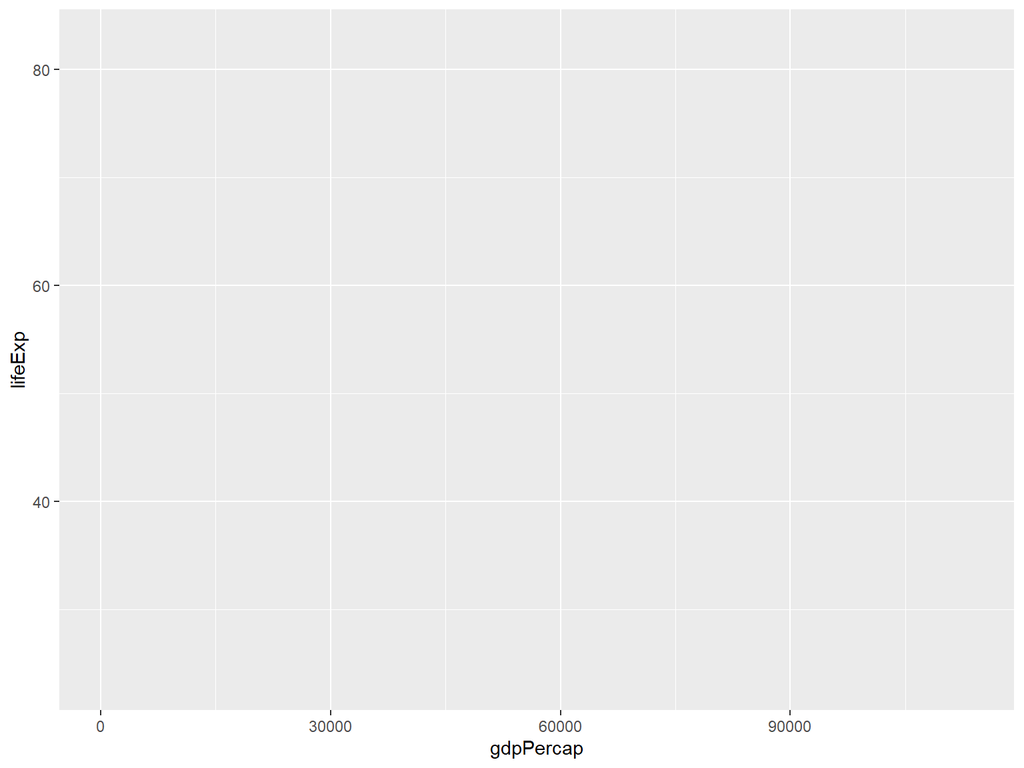

```r
ggplot(data = gapminder, mapping = aes(x = gdpPercap, y = lifeExp))
```

Something is missing … 🤔 We need an additional layer, a `geom_*` function!

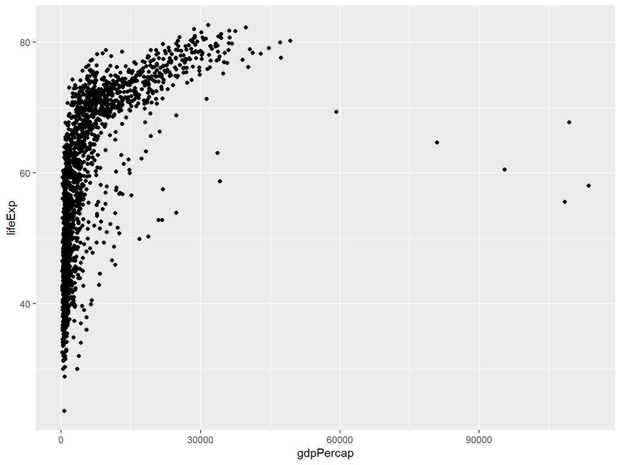

```r
ggplot(data = gapminder, mapping = aes(x = gdpPercap, y = lifeExp)) +
  geom_point()
```

There are more of them which we can simply add (literally add!):

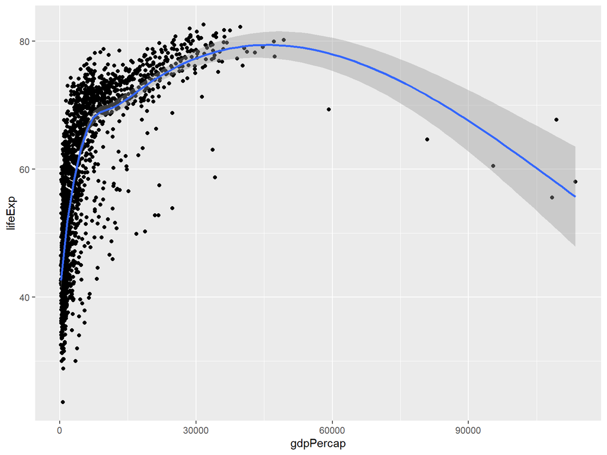

```r
p <- ggplot(data = gapminder, mapping = aes(x = gdpPercap, y = lifeExp))
p <- p + geom_point() + geom_smooth()
p
```

As a last polishing step for now, we improve the x-axis scale and the plot labels.

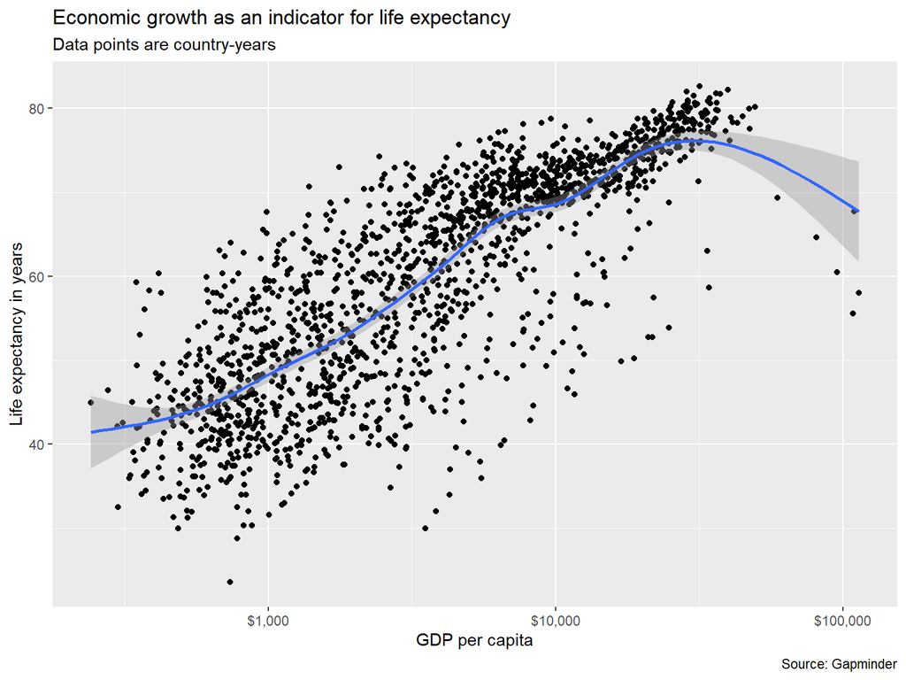

```r
p + scale_x_log10(labels = scales::dollar) +
  labs(x = "GDP per capita",
       y = "Life expectancy in years",
       title = "Economic growth as an indicator for life expectancy",
       subtitle = "Data points are country-years",
       caption = "Source: Gapminder")
```

Finally, we can use the `ggsave()` function to save our plot:

```r
ggsave("some_descriptive_name.pdf")
```

### The {ggplot2} workflow

1. Call `ggplot()`
2. Set `data = ...`
3. Set `mapping = aes(...)`
4. Add one (or more) `geom_*()` functions
5. Adjust the scale and labels

# It’s your turn

This course includes tutorials! 😎

Executing the following lines gives you access to the course material:

```r
# install.packages("devtools")
devtools::install_github("loelschlaeger/howtoggplot2")
library(howtoggplot2)
```

To start the tutorial, type:

```r
practicals()
```

To open a copy of these slides, type:

```r
slides()
```

To submit an issue on GitHub about this course, type:

```r
issue()
```

# Facets and more geoms

Our goal is to plot the trajectory of life expectancy over time for each country in the gapminder data.

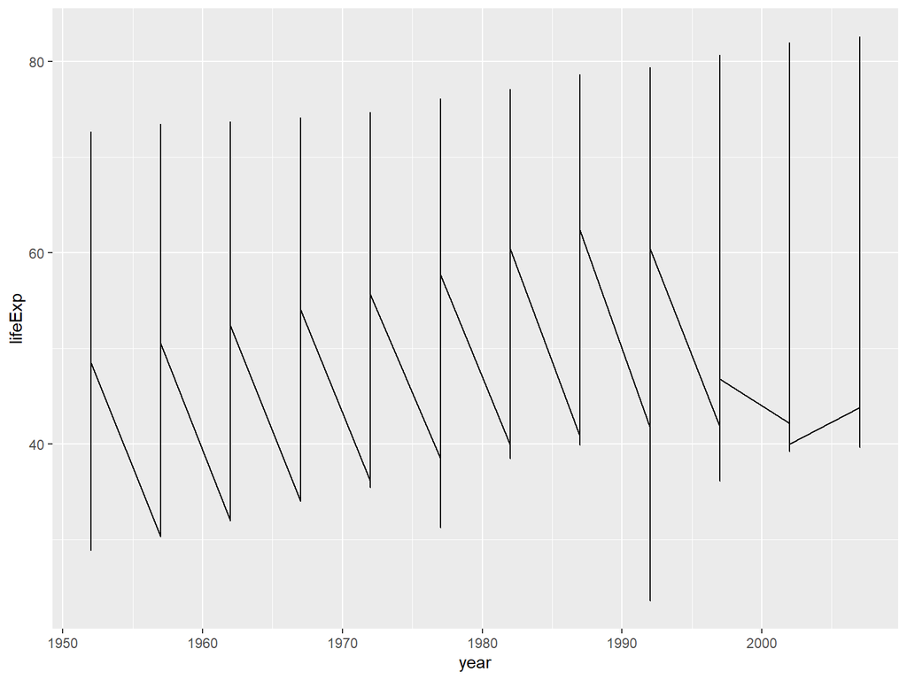

```r
ggplot(data = gapminder, mapping = aes(x = year, y = lifeExp)) +
  geom_line()
```

We must not forget to group by country! 💡

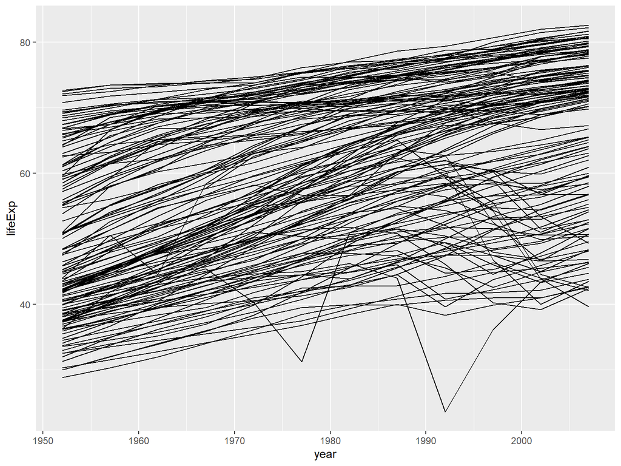

```r
ggplot(data = gapminder, mapping = aes(x = year, y = lifeExp)) +
  geom_line(aes(group = country))
```

But can you make sense of this mess? Luckily, we can group by continents:

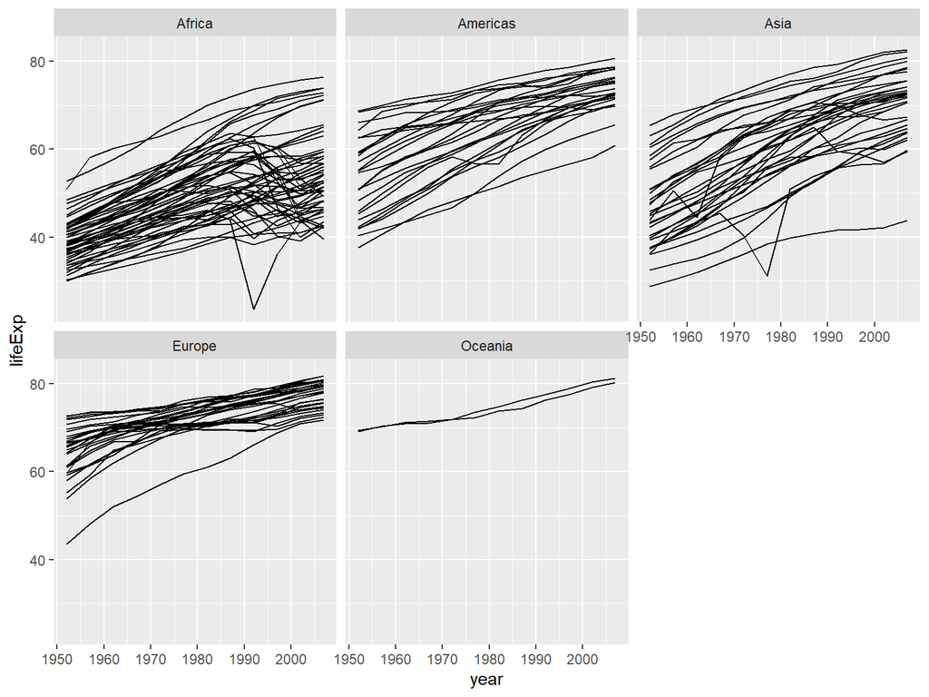

```r
ggplot(data = gapminder, mapping = aes(x = year, y = lifeExp)) +
  geom_line(aes(group = country)) +
  facet_wrap(~continent)
```

Better don’t `facet_wrap(~country)`… Let’s polish our plot with the things we already learned:

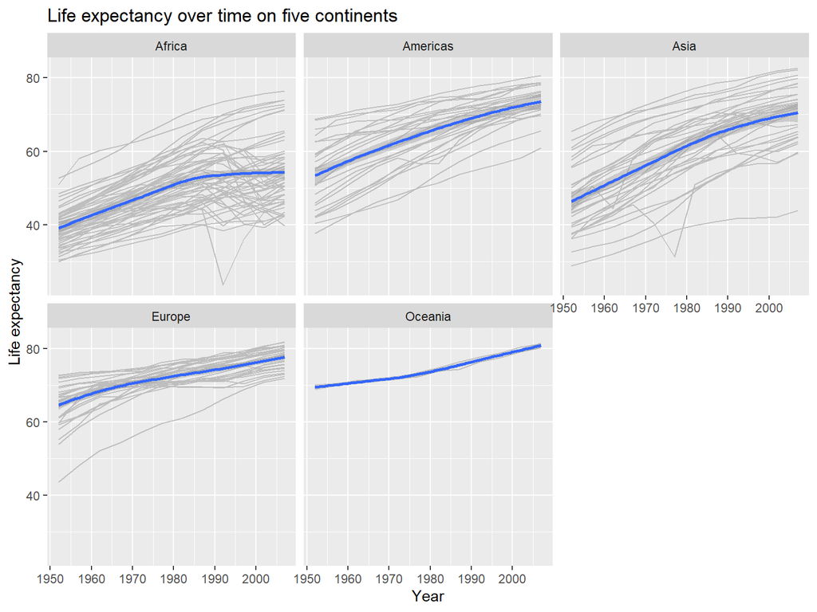

```r
ggplot(data = gapminder, mapping = aes(x = year, y = lifeExp)) +
  geom_line(color = "grey", aes(group = country)) +
  geom_smooth() +
  facet_wrap(~continent) +
  labs(x = "Year",
       y = "Life expectancy",
       title = "Life expectancy over time on five continents")
```

Notice that we supplied a formula to `facet_wrap`. This can be more advanced, for example (with `facet_grid`):

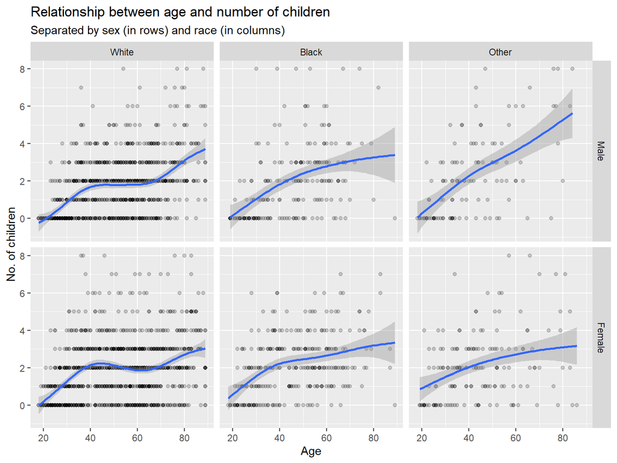

```r
ggplot(data = socviz::gss_sm, mapping = aes(x = age, y = childs)) +
  geom_point(alpha = 0.2) +
  geom_smooth() +
  facet_grid(sex ~ race) +
  labs(x = "Age",
       y = "No. of children",
       title = "Relationship between age and number of children",
       subtitle = "Separated by sex (in rows) and race (in columns)")
```

As a last input for this part, we learn four new geoms.

### Bar plots

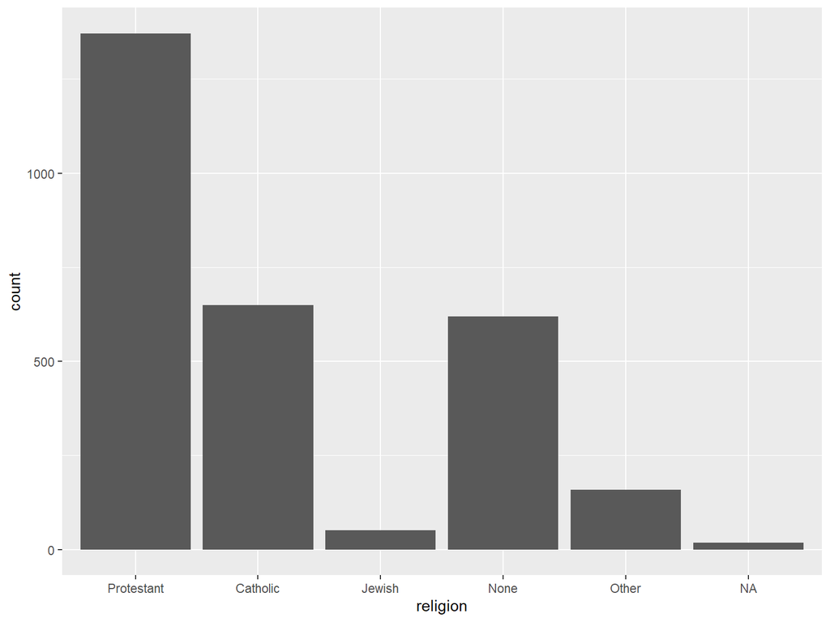

```r
ggplot(data = socviz::gss_sm, mapping = aes(x = religion)) +
  geom_bar()
```

Using relative instead of absolute counts on the y-axis is covered in the tutorials.

### Histograms

```
## Warning: Removed 10 rows containing non-finite values (stat_bin).
```

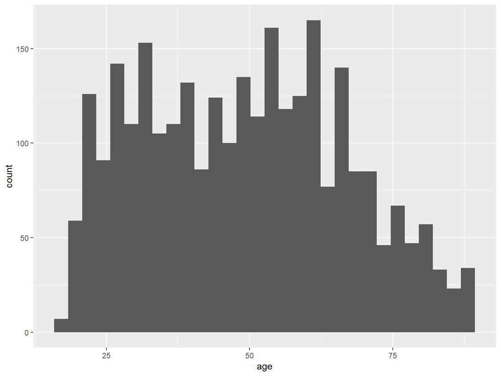

```r
ggplot(data = socviz::gss_sm, mapping = aes(x = age)) +
  geom_histogram()
```

We address the message and the warning in the tutorials.

### Density plots

```r
library(dplyr)
```

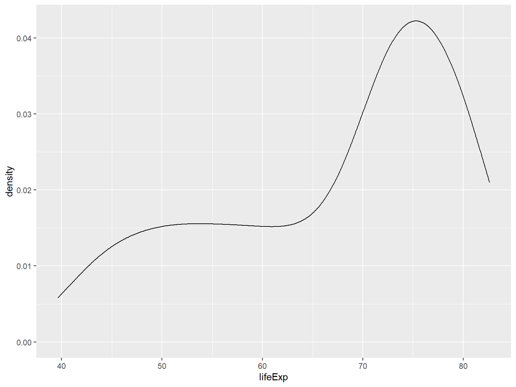

```r
ggplot(data = filter(gapminder, year == 2007),
       mapping = aes(x = lifeExp)) +
  geom_density()
```

### Boxplots

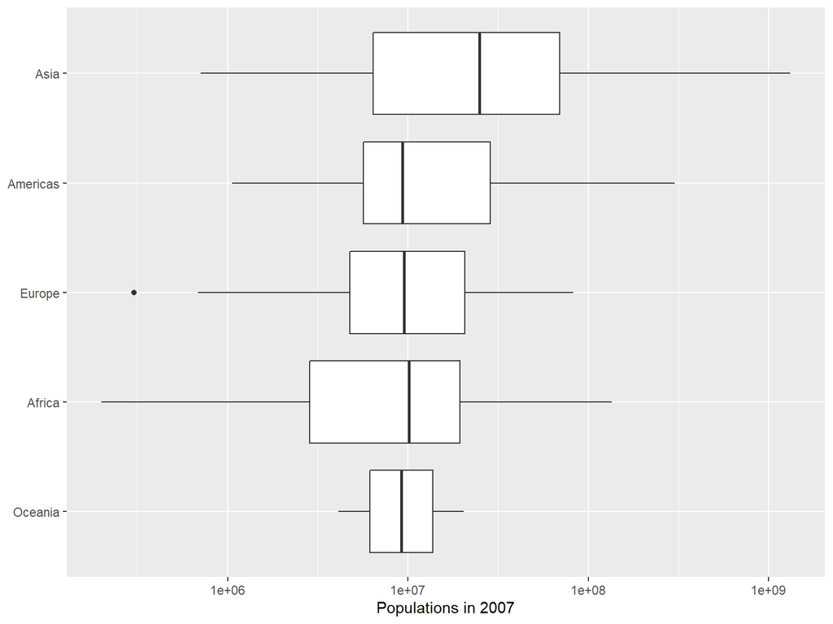

```r
ggplot(data = filter(gapminder, year == 2007),
       mapping = aes(x = pop,
                     y = reorder(continent, pop))) +
  geom_boxplot() +
  scale_x_log10() +
  labs(y = NULL,
       x = "Populations in 2007")
```

We look at a variant on the basic boxplot that {ggplot2} offers in the tutorials.

# Annotations

We can plot text annotations to plots via `geom_text()`:

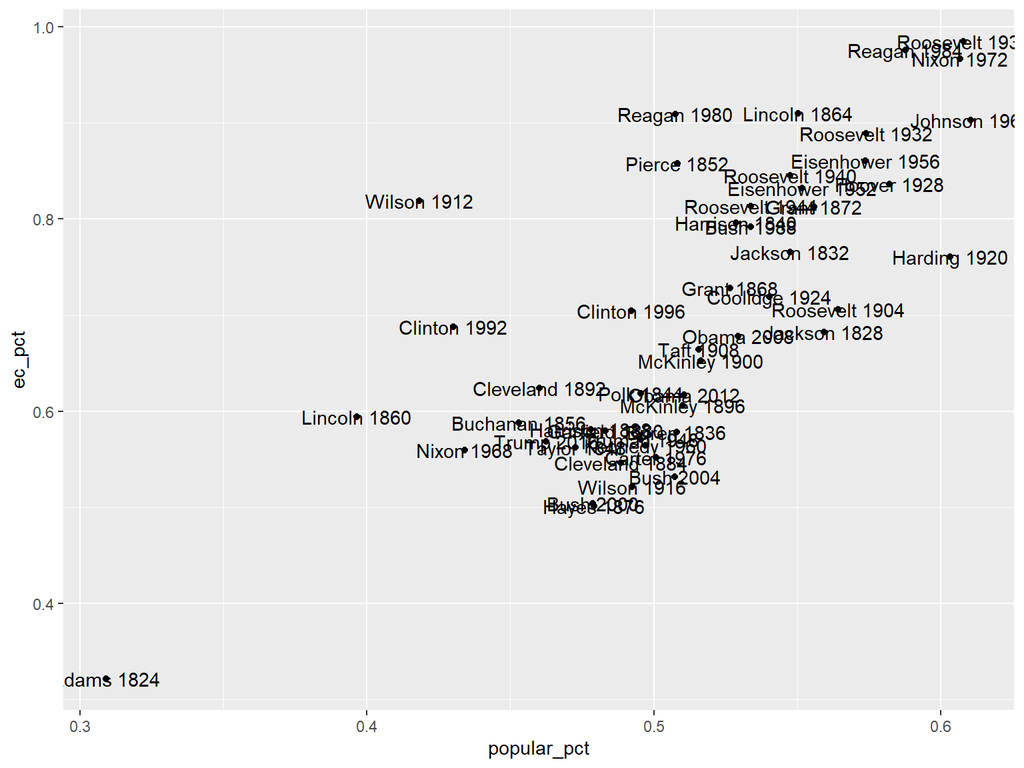

```r
ggplot(data = socviz::elections_historic,
       mapping = aes(x = popular_pct,
                     y = ec_pct,
                     label = winner_label)) +
  geom_point() +
  geom_text()
```

This is hard to read. Adjusting the position is possible, but it is fuzzy and not robust. The extension {ggrepel} is designed to do this task for us:

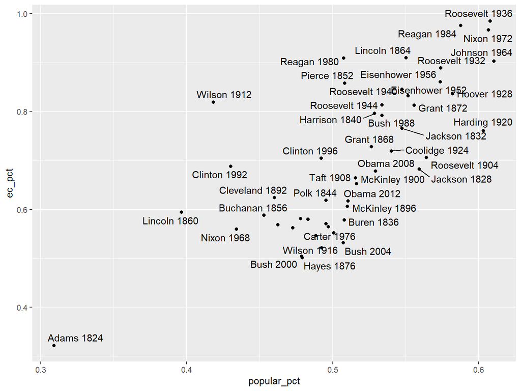

```r
ggplot(data = socviz::elections_historic,
       mapping = aes(x = popular_pct,
                     y = ec_pct,
                     label = winner_label)) +
  geom_point() +
  ggrepel::geom_text_repel()
```

We can also annotate only selected points (outliers for example) like follows:

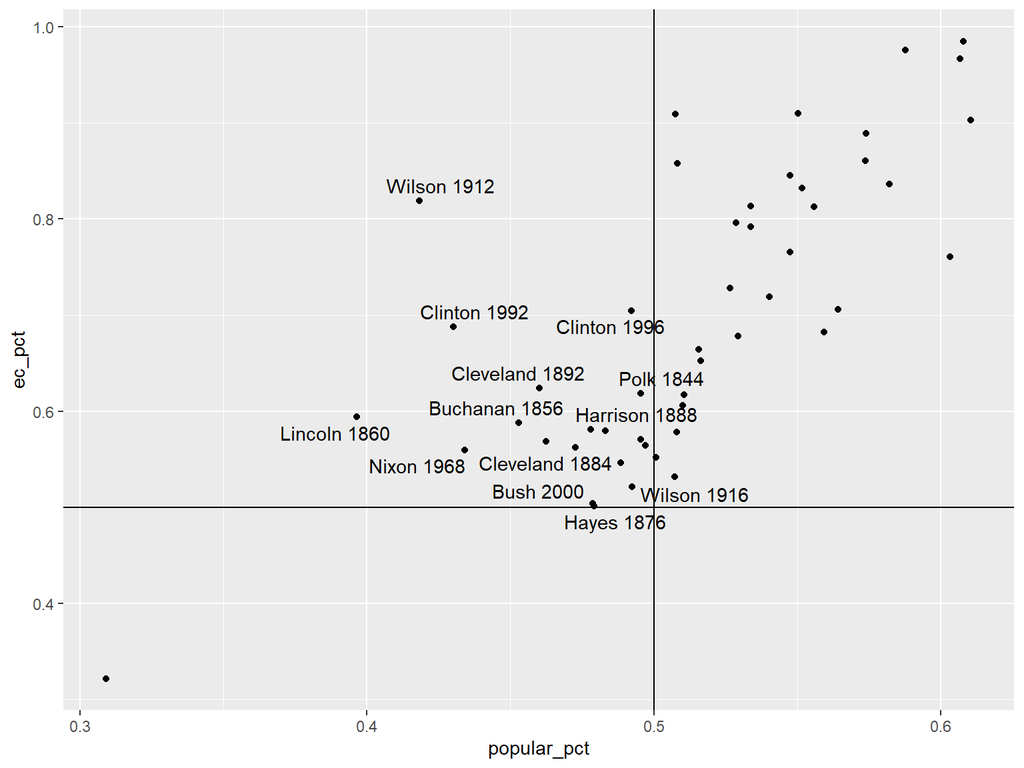

```r
ggplot(data = socviz::elections_historic,
       mapping = aes(x = popular_pct,
                     y = ec_pct,
                     label = winner_label)) +
  geom_point() +
  ggrepel::geom_text_repel(
    data = filter(socviz::elections_historic, popular_pct < 0.5 & ec_pct > 0.5)
  ) +
  geom_hline(yintercept = 0.5) +
  geom_vline(xintercept = 0.5)
```

And finally, we can annotate anywhere almost everything we wish via `annotate()`:

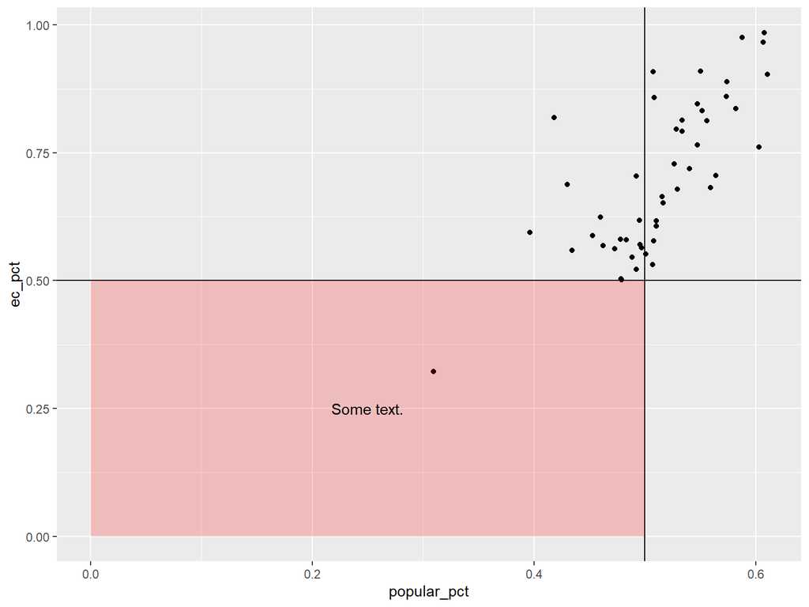

```r
ggplot(data = socviz::elections_historic,
       mapping = aes(x = popular_pct,
                     y = ec_pct,
                     label = winner_label)) +
  geom_point() +
  geom_hline(yintercept = 0.5) +
  geom_vline(xintercept = 0.5) +
  annotate(geom = "rect", xmin = 0, xmax = 0.5, ymin = 0, ymax = 0.5, fill = "red", alpha = 0.2) +
  annotate(geom = "text", x = 0.25, y = 0.25, label = "Some text.")
```

# Draw Maps

R can work with geographical data, and {ggplot2} can make [choropleth maps](https://en.wikipedia.org/wiki/Choropleth_map).

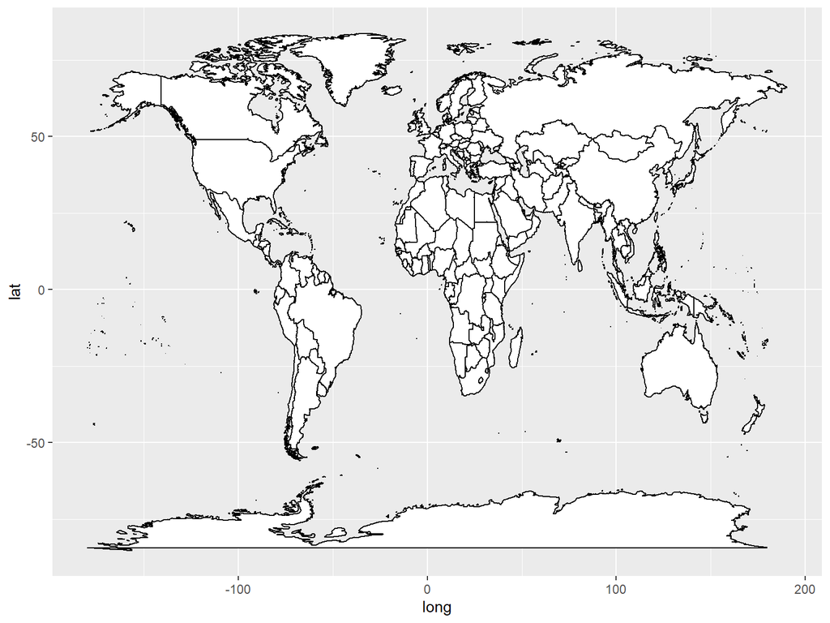

```r
world <- map_data("world")
p <- ggplot(data = world, aes(x = long, y = lat, group = group)) +
  geom_polygon(fill = "white", color = "black")
plot(p)
```

Instead of the default [Mercator projection](https://en.wikipedia.org/wiki/Mercator_projection), we can use the [Albers projection](https://en.wikipedia.org/wiki/Albers_projection):

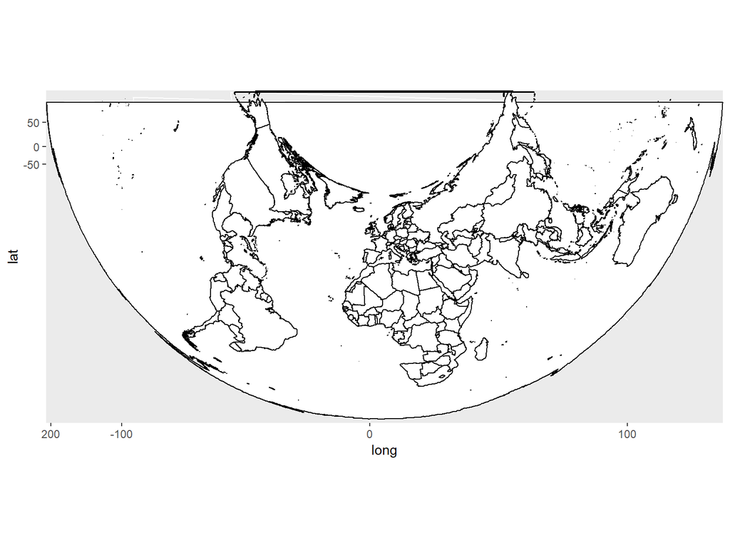

```r
p + coord_map(projection = "albers", lat0 = 15, lat1 = 45)
```

Now in the tutorials, we will visualize the results of the Trump vs. Clinton election 2016 on a map of the US states.